# Poverty and Test Performance in New York Public Schools

Puhua Ye

## Question

This project studies the relationship between poverty and test performance in New York public schools.

## Data and method

The project uses school performance data and county ACS data. Duplicate rows were removed, and `-99` values were changed to missing values. Counties were divided into low, medium, and high poverty groups. Test scores were standardized within each year. The two datasets were joined by county and year.

## Poverty and test performance

| poverty_group | number_of_schools | mean_reading_score | mean_math_score |
| --- | --- | --- | --- |
| low | 1496 | 0.38 | 0.32 |
| medium | 1580 | -0.02 | -0.02 |
| high | 2102 | -0.27 | -0.23 |

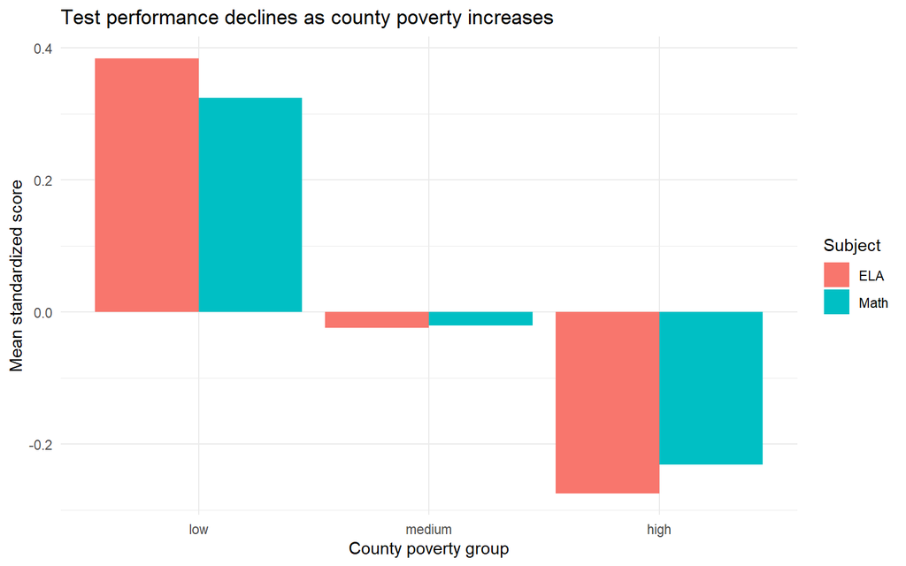

Schools in high-poverty counties have lower average reading and math scores. Schools in low-poverty counties have the highest average scores.

## Change over time

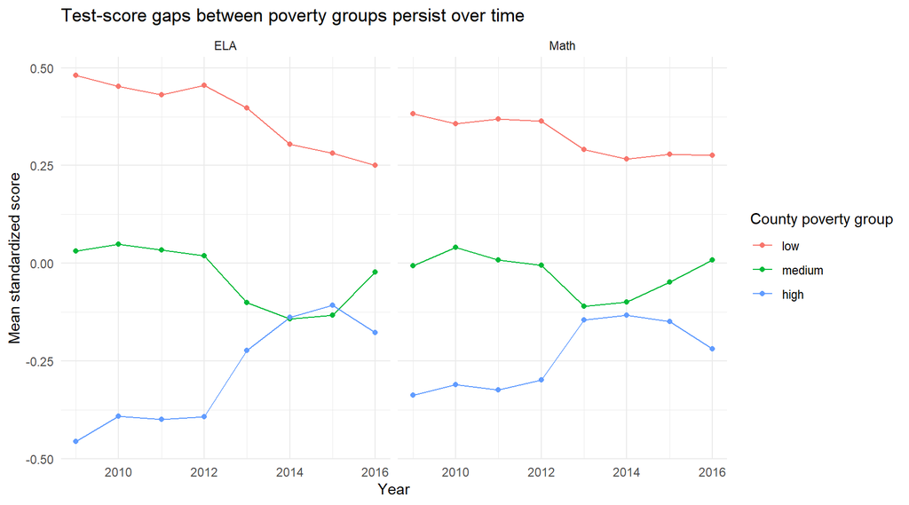

The score gap between low- and high-poverty groups appears in every year. The size of the gap changes, but it does not disappear.

## Free and reduced-price lunch

| poverty_group | lunch_group | number_of_schools | mean_reading_score | mean_math_score |
| --- | --- | --- | --- | --- |
| low | low | 985 | 0.84 | 0.75 |
| low | medium | 637 | -0.10 | -0.12 |
| low | high | 234 | -0.96 | -0.97 |
| medium | low | 616 | 0.71 | 0.65 |
| medium | medium | 867 | -0.05 | -0.04 |
| medium | high | 507 | -0.92 | -0.85 |
| high | low | 373 | 0.92 | 0.81 |
| high | medium | 1088 | 0.01 | 0.04 |
| high | high | 1315 | -0.66 | -0.58 |

Within each poverty group, schools with higher lunch eligibility have lower average scores. Lunch eligibility provides additional information about school poverty and test performance.

## Conclusion

Higher poverty is associated with lower test performance. This relationship continues over time and is also visible in school lunch eligibility. These results describe an association and do not prove that poverty causes lower test scores.